# Budding index of Gat201 strains

Edward Wallace

20/03/2023

## Summary

This plots the budding index (% of cells with buds) for Cryptococcus cells with and without Gat201, in wakeup conditions.

Data were collected by Liz Ballou, 2022-08-11. Additional cell counts added 2024-06.

In brief, $10^6$ stationary phase cells were resuspended in the appropriate pre-warmed medium as indicated to a final volume of 10 ml each. Cells were incubated in the indicated condition for 120 minutes, and then the entire pellet was collected and fixed with 4% methanol free formaldehyde (Pierce) for 10 minutes, then washed 3x with PBS. India ink (Remel) slides were prepared and cells were imaged using an inverted Zeiss AxioObserver Z1 with a Plan-Neofluor 40X/1.3 numerical aperture (NA) oil immersion lens objective (Carl Zeiss) and a 16-bit CoolSNAP H2 charge-coupled-device (CCD) camera (Photometrics).

For each figure, three biological replicates were initiated using independent stationary cultures and collected serially on the same day. The entire experiment was performed independently two times. Cells were counted by eye, each assigned as budded or unbudded.

Data from file `20220811_CryptoWakeup_Gat201_budding_quantification.xlsx`.

### Load shared functions and formatting

## Set up strain names, colours, etc.

```r
strain_df <- tibble( Strain = c("H99", "gat201", "C26 GAT201", "C30" ),
                     Strain_nice = c("GAT201", "gat201∆m", "GAT201-C1", "GAT201-C2"),
                     colour = c("grey20", "darkred", "blue3", "cyan4"))

scale_color_strain <-
  scale_color_manual("Strain",
                     breaks = strain_df$Strain_nice,
                     values = strain_df$colour)

Time_Media_Temp_levels <-
  c("0min YPD 25",
    "120min YPD 25", "120min YPD 37",
    "120min RPMI 25", "120min RPMI 37")

Time_Media_Temp_labels <-
  c("0hr\nYPD",
    "2hr\nYPD\n25°C",  "2hr\nYPD\n37°C",
    "2hr\nRPMI\n25°C", "2hr\nRPMI\n37°C")
```

## Read in data as xlsx file

```r
budding_data <-
  here::here("data","20220811_CryptoWakeup_Gat201_budding_quantification.xlsx") %>%
  readxl::read_excel() %>%
  dplyr::filter(!is.na(total_cells)) %>%
  tidyr::separate(condition,
                  into = c("Replicate", "Media", "Temperature", "Time_min"),
                  remove = FALSE) %>%
  dplyr::mutate(Time_Media_Temp =
                  paste(Time_min, Media, Temperature) %>%
                  factor(levels = Time_Media_Temp_levels,
                         labels = Time_Media_Temp_labels)
                ) %>%
  dplyr::left_join(strain_df, by = "Strain")
```

## Summarise budding index by sample (strain and replicate)

```r
budding_data_bysample <-
  budding_data %>%
  group_by(Strain_nice, condition, Replicate, Time_Media_Temp) %>%
  summarize(unbudded = sum(unbudded),
            budded = sum(budded),
            total_cells = sum(total_cells),
            budding_index = budded/total_cells * 100,
            .groups = "keep")

budding_data_bysample
```

```
## # A tibble: 44 × 8
## # Groups:   Strain_nice, condition, Replicate, Time_Media_Temp [44]
##    Strain_nice condition   Replicate Time_Media_Temp unbudded budded total_cells
##    <chr>       <chr>       <chr>     <fct>              <dbl>  <dbl>       <dbl>
##  1 GAT201      rep1 RPMI … rep1      "2hr\nRPMI\n25…      185      4         189
##  2 GAT201      rep1 RPMI … rep1      "2hr\nRPMI\n37…      204      1         205
##  3 GAT201      rep1 YPD 2… rep1      "0hr\nYPD"           282      0         282
##  4 GAT201      rep1 YPD 2… rep1      "2hr\nYPD\n25°…      310     12         322
##  5 GAT201      rep1 YPD 3… rep1      "2hr\nYPD\n37°…      152     10         162
##  6 GAT201      rep2 RPMI … rep2      "2hr\nRPMI\n25…      310      0         310
##  7 GAT201      rep2 RPMI … rep2      "2hr\nRPMI\n37…      347      3         350
##  8 GAT201      rep2 YPD 2… rep2      "0hr\nYPD"           363      0         363
##  9 GAT201      rep2 YPD 2… rep2      "2hr\nYPD\n25°…      175     10         185
## 10 GAT201      rep2 YPD 3… rep2      "2hr\nYPD\n37°…      177     12         189
## # ℹ 34 more rows
## # ℹ 1 more variable: budding_index <dbl>
```

## Plot the budding index by strain and replicate

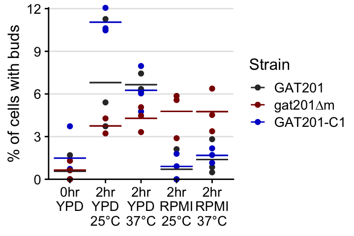

```r
budding_index_plot <-
  ggplot(data = budding_data_bysample %>%
           dplyr::filter(!is.na(total_cells)),
         aes(x = Time_Media_Temp, y = budding_index, colour = Strain_nice)) +
  geom_point() +
  stat_summary(geom = "errorbar", fun.max = "mean", fun.min = "mean") +
  scale_color_strain +
  scale_y_continuous("% of cells with buds", expand = c(0,0)) +
  coord_cartesian(clip = "off") +
  theme(axis.title.x = element_blank(),
        panel.border = element_blank())

budding_index_plot
```

## Save plot to .svg and .png format

```r
here::here("results", "budding_index_Time_Media_Temp.png") %>%
  ggsave(plot = budding_index_plot,
         width = 3.75, height=2)
```

```r
here::here("results", "budding_index_Time_Media_Temp.svg") %>%
  ggsave(plot = budding_index_plot,
         width = 3.75, height=2)
```